# SEPTA COVID Data Visualization

Andrew Simpson

5/20/2020

## Data Generation

See GitHub repository for documentation of methodology and approach. In short, data is taken from weekly samples of SEPTA bus APC data and is used to generate daily ridership at each stop. The data is not comprehensive and it is not well audited/cleaned, but it is the best snapshot of what has happened to transit ridership on a weekly basis through this crisis.

### Data Sources:

Data was taken from:

- SEPTA Automated Passenger Count Date + Turnstile Data (Not yet incorporated)
- ACS 2018 5-Year Estimates
- Misc. shapes pulled from opendataphilly

## Visualizing the Data

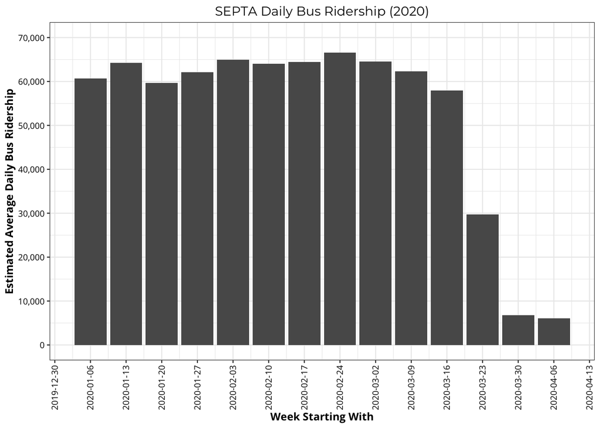

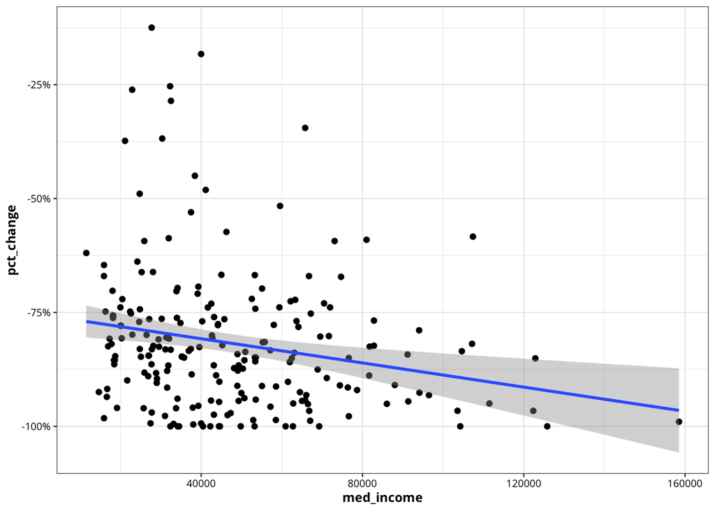

### Examining Ridership by Census Tract

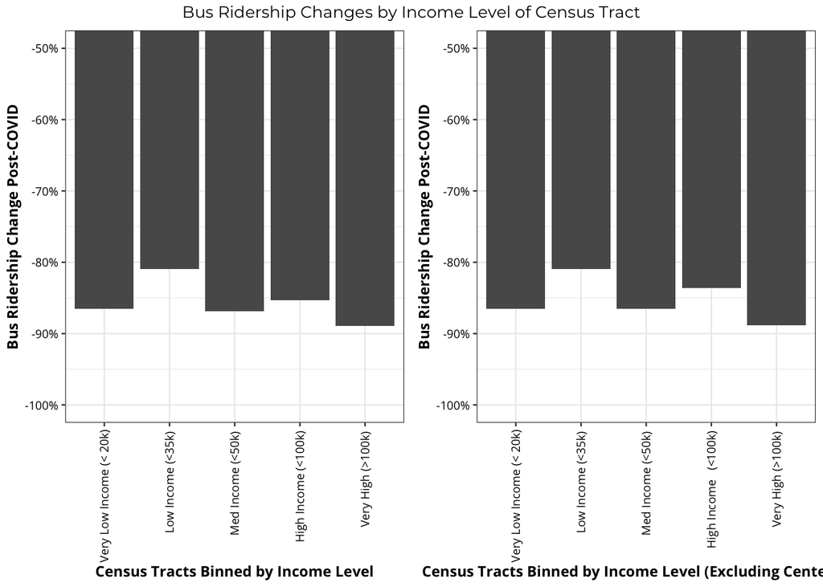

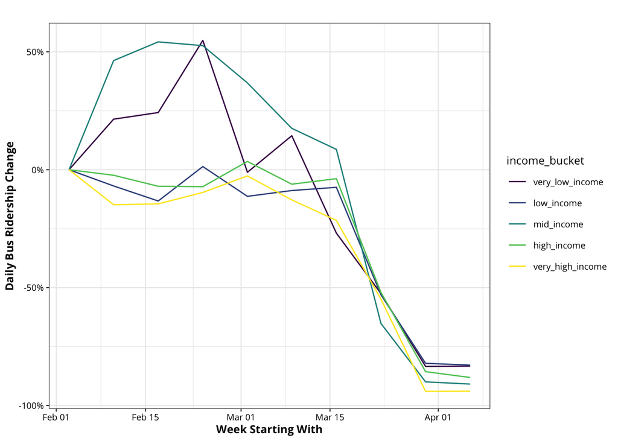

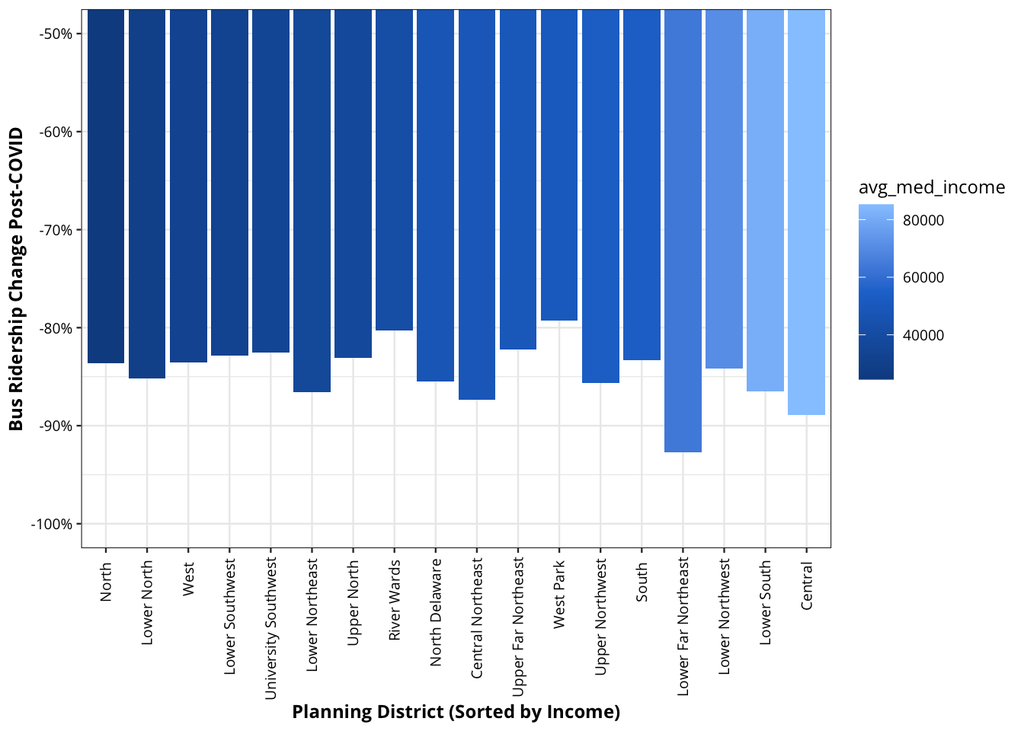

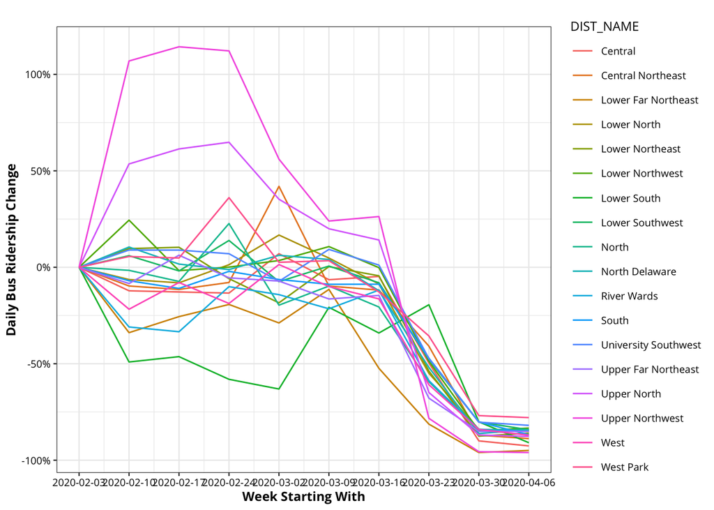

## Modeling Behavior

Goal here will be to look back and see what demographics were key predictors of a neighobrhood’s ability to isolate and limit travel via transit.

Things to look at:

- Income
- Race
- Car Ownership
- Education
- commute modes
- industry characteristics

Note: this assumes that the bus ridership of a neighborhood mirrors the demographic makeup of a neighborhood, which we know is not very true. Bus ridership in a neighobhrood is going to be composed of people with certain characteristics - e.g. work destinations that are transit accessible; lower incomes; and probably more.

Other path to look at: route level ridership loaded w/ surveyed rider demographics (pending data from SEPTA).